# Exploring thresholds for filtering based on tumor purity

SJ Spielman for CCDL

2023

This notebook explores potential tumor purity thresholds that could be applied in other contexts to assess the influence of tumor purity on certain RNA-level analyses. Note that RNA-level analyses this pertains to focus only on stranded samples, so any assessments and figures here will focus on stranded libraries only.

## Functions

This section defines some functions which are needed in this (and only for this!) notebook.

```r
# This is a helper function to calculated weighted means for tumor_fraction,
# weighted across either broad_histology_display or cancer_group_display groups
calc_weighted_mean <- function(df, group_var) {
  df %>%
    drop_na(tumor_fraction) %>%
    add_count({{group_var}}) %>%
    mutate(contribution = tumor_fraction * (n/sum(n))) %>%
    summarize(weighted = sum(contribution)) %>%
    pull(weighted)
}

# This function calculates the fraction of counts in a given group that would
# remain after a given universal threshold is applied
calc_frac <- function(df,
                      threshold,
                      group_var) {
  # establish total counts
  total_count <- df %>%
    count({{group_var}}, name = "total")

  df %>%
    filter(tumor_fraction <= threshold) %>%
    # count after filtering
    count({{group_var}}) %>%
    # divide after/before
    inner_join(total_count) %>%
    mutate(frac_remaining = n/total) %>%
    distinct()
}


# This function makes a barplot showing the remaining fraction of samples after
#  thresholding `mean_threshold` or `median_threshold`
plot_remaining_frac <- function(df,
                                mean_threshold,
                                median_threshold,
                                group_var) {

  remaining_df <- bind_rows(
    calc_frac(df, mean_threshold, {{group_var}}) %>%
      mutate(threshold = "mean threshold"),
    calc_frac(df, median_threshold, {{group_var}}) %>%
      mutate(threshold = "median threshold")
  )

  ggplot(remaining_df) +
    aes(x = {{group_var}},
        y = frac_remaining,
        fill = threshold) +
    geom_col(color = "black", size = 0.5,
             position = position_dodge()) +
    geom_hline(yintercept = 0.5) +
    theme(axis.text.x = element_text(angle = 30, hjust = 1))
}

# This function makes a barplot showing the remaining fraction of samples after
#   applying a per-group threshold. The inputted df is assumed to have been thresholded already
plot_remaining_frac_group_threshold <- function(df, var, title, fill) {
  ggplot(df,
         aes(x = {{var}}, y = percent_remaining)) +
    geom_col(fill = fill, color = "black" ) +
    geom_text(aes(y = percent_remaining+0.025, label = count_remaining),
              color = "red") +
    labs(
      y = "Percent of samples that remain after thresholding",
      title = title,
      subtitle = "text labels are remaining counts"
    ) +
    theme(axis.text.x = element_text(angle = 30, size = 8, hjust = 1)) +
    ylim(c(0,1))
}
```

## Set directories and files

```r
root_dir <- rprojroot::find_root(rprojroot::has_dir(".git"))
data_dir <- file.path(root_dir, "data")
pal_dir <- file.path(root_dir, "figures", "palettes")

results_dir <- file.path("results")
if (!(dir.exists(results_dir))) {
  dir.create(results_dir)
}

metadata_file <- file.path(data_dir, "pbta-histologies.tsv")
pal_file <- file.path(pal_dir, "broad_histology_cancer_group_palette.tsv")
rna_stranded_df_file <- file.path(results_dir, "rna_stranded_same-extraction.tsv")  # 01 notebook output


rna_stranded_thresholded_df_file <- file.path(results_dir, "thresholded_rna_stranded_same-extraction.tsv")
```

Read in:

```r
palette_mapping_df <- read_tsv(pal_file)
metadata <- read_tsv(metadata_file)
rna_stranded_df <- read_tsv(rna_stranded_df_file)
```

## Exploring thresholding

If we were to potentially limit analyses to only tumors with a certain level of purity, how would that affect sample distributions? In particular, how many samples would be left from each grouping if we removed at a certain threshold which might be, for example…

- Overall unweighted median or mean tumor fraction
- Weighted mean by group-size tumor fraction (but what is the grouping variable?)

First let’s join the new `rna_stranded_df` with the palette.

```r
rna_stranded_df <- rna_stranded_df %>%
  inner_join(
    select(metadata,
           Kids_First_Biospecimen_ID,
           cancer_group,
           broad_histology)
  ) %>%
  inner_join(palette_mapping_df) %>%
  select(Kids_First_Biospecimen_ID,
         tumor_fraction,
         cancer_group_display,
         cancer_group_hex,
         broad_histology_display,
         broad_histology_order,
         broad_histology_hex) %>%
  drop_na() %>%
  # reorder by median fraction and ensure "Other" is always last
  mutate(cancer_group_display = forcats::fct_reorder(cancer_group_display, tumor_fraction),
         cancer_group_display = forcats::fct_relevel(cancer_group_display, "Other", after = Inf),
         broad_histology_display = forcats::fct_reorder(broad_histology_display, tumor_fraction),
         broad_histology_display = forcats::fct_relevel(broad_histology_display, "Other", after = Inf))
```

Let’s look at these threshold themselves:

```r
median_tumor <- median(rna_stranded_df$tumor_fraction, na.rm = TRUE)
cat("median", median_tumor)
```

```
median 0.7570031
```

```r
unweighted_mean <- mean(rna_stranded_df$tumor_fraction, na.rm = TRUE)
cat("\nunweighed mean", unweighted_mean)
```

```
unweighed mean 0.6993561
```

```r
weighted_mean_bh <- calc_weighted_mean(rna_stranded_df, broad_histology_display)
cat("\nweighted_mean_bh", weighted_mean_bh)
```

```
weighted_mean_bh 0.6969367
```

```r
weighted_mean_cg <- calc_weighted_mean(rna_stranded_df, cancer_group_display)
cat("\nweighted_mean_cg", weighted_mean_cg)
```

```
weighted_mean_cg 0.7111655
```

The weighted means are about the same as the overall mean, which is somewhat lower than the overall median.

Let’s explore what fraction of samples remain when filtering down based on the **median** and means at both broad histology and cancer group levels. The y-axes show how the fraction of samples which would remain after filtering, and horizontal lines are 50% guides.

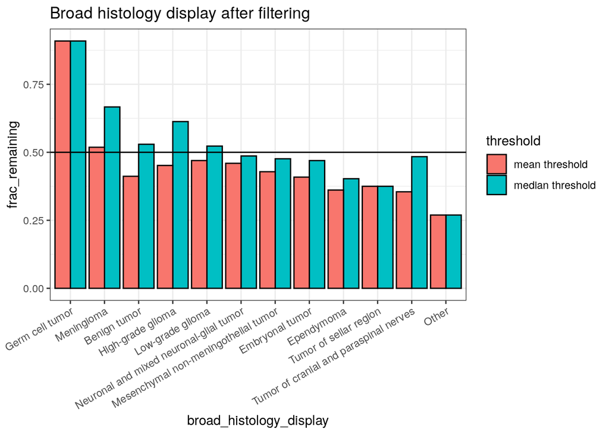

```r
plot_remaining_frac(rna_stranded_df,
                    unweighted_mean,
                    median_tumor,
                    broad_histology_display) +
  ggtitle("Broad histology display after filtering")
```

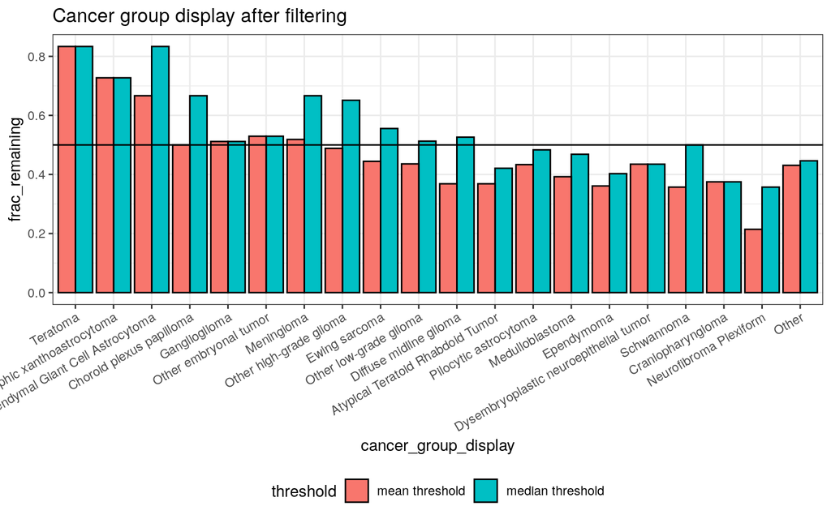

```r
plot_remaining_frac(rna_stranded_df,
                    unweighted_mean,
                    median_tumor,
                    cancer_group_display) +
  theme(legend.position = "bottom") +
  ggtitle("Cancer group display after filtering")
```

### Thresholding within groups

Rather than considering a single global threshold, how would this look if we did a *per group* threshold? Specifically, let’s see how this looks if we use the *per cancer-group median* as the threshold and filter from there. In addition, we may wish to impose a global minimum to ensure that all samples that at least some baseline tumor fraction level.

```r
# Ensure that all samples have at least 0.7 tumor purity
global_minimum <- 0.7

cancer_group_thresholds_df <- rna_stranded_df %>%
  group_by(cancer_group_display) %>%
  summarize(cancer_group_tumor_threshold = median(tumor_fraction),
            n_tumors = n())

# Just something to count up the total bh for later division
total_bh_df <- rna_stranded_df %>%
  count(broad_histology_display, name = "n_tumors")
```

Now we can see how many samples would be retained:

```r
rna_stranded_df_thresholded <- rna_stranded_df %>%
  inner_join(cancer_group_thresholds_df) %>%
  # Pass both thresholds
  filter(tumor_fraction >= global_minimum,
         tumor_fraction >= cancer_group_tumor_threshold) %>%
  unique() %>%
  # bring back the sample_id which may be needed in other contexts
  inner_join(
    select(metadata,
           Kids_First_Biospecimen_ID,
           sample_id)
  )
# How many cancer groups?
remaining_cg <- rna_stranded_df_thresholded %>%
  count(cancer_group_display, name = "count_remaining") %>%
  # join again to get n_tumors
  inner_join(cancer_group_thresholds_df) %>%
  mutate(percent_remaining = count_remaining/n_tumors)
remaining_cg
```

| cancer_group_display | count_remaining | cancer_group_tumor_threshold | n_tumors | percent_remaining |
| --- | --- | --- | --- | --- |
| Teratoma | 1 | 0.4742911 | 6 | 0.1666667 |
| Pleomorphic xanthoastrocytoma | 3 | 0.4816804 | 11 | 0.2727273 |
| Subependymal Giant Cell Astrocytoma | 4 | 0.5034728 | 12 | 0.3333333 |
| Choroid plexus papilloma | 6 | 0.6502549 | 12 | 0.5000000 |
| Ganglioglioma | 21 | 0.6631956 | 43 | 0.4883721 |
| Other embryonal tumor | 8 | 0.6843914 | 17 | 0.4705882 |
| Meningioma | 13 | 0.6967063 | 27 | 0.4814815 |
| Other high-grade glioma | 22 | 0.7020093 | 43 | 0.5116279 |
| Ewing sarcoma | 5 | 0.7464905 | 9 | 0.5555556 |
| Other low-grade glioma | 39 | 0.7516152 | 78 | 0.5000000 |

[output cut: 10 more lines]

```r
# How many broad histologies groups?
remaining_bh <- rna_stranded_df_thresholded %>%
  count(broad_histology_display, name = "count_remaining") %>%
  # join again to get n_tumors
  inner_join(total_bh_df) %>%
  mutate(percent_remaining = count_remaining/n_tumors)
remaining_bh
```

| broad_histology_display | count_remaining | n_tumors | percent_remaining |
| --- | --- | --- | --- |
| Germ cell tumor | 1 | 11 | 0.09090909 |
| Meningioma | 13 | 27 | 0.48148148 |
| Benign tumor | 10 | 17 | 0.58823529 |
| High-grade glioma | 32 | 62 | 0.51612903 |
| Low-grade glioma | 127 | 264 | 0.48106061 |
| Neuronal and mixed neuronal-glial tumor | 17 | 37 | 0.45945946 |
| Mesenchymal non-meningothelial tumor | 11 | 21 | 0.52380952 |
| Embryonal tumor | 58 | 115 | 0.50434783 |
| Ependymoma | 36 | 72 | 0.50000000 |
| Tumor of sellar region | 16 | 32 | 0.50000000 |

[output cut: 2 more lines]

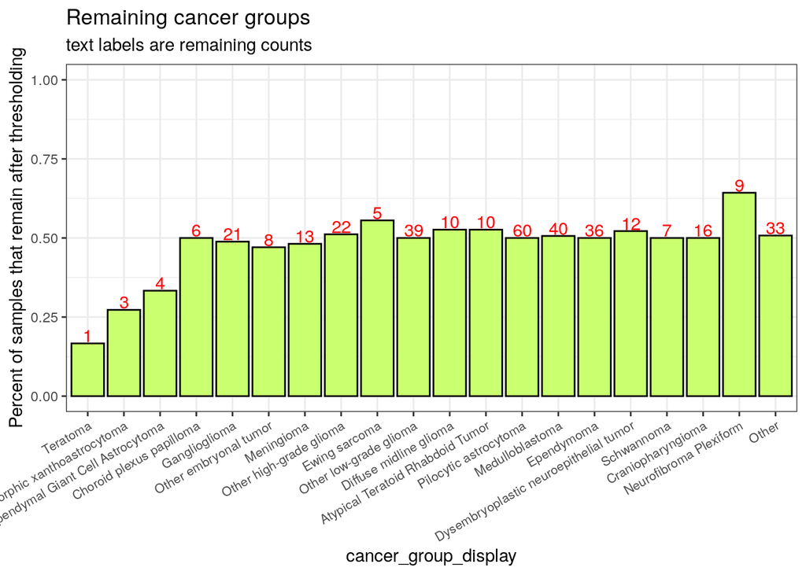

```r
plot_remaining_frac_group_threshold(remaining_cg, cancer_group_display, "Remaining cancer groups", "darkolivegreen1")
```

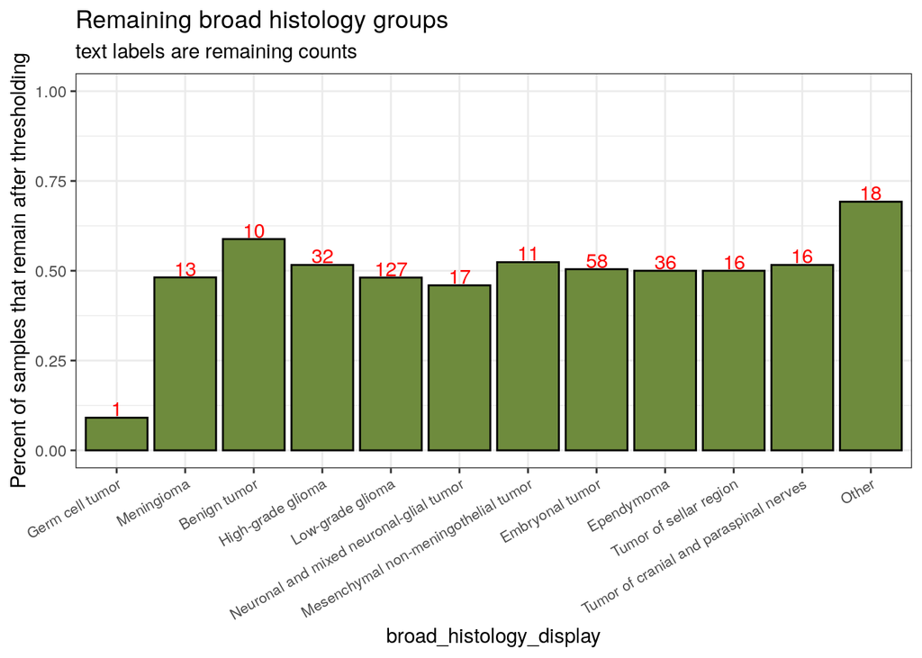

```r
plot_remaining_frac_group_threshold(remaining_bh, broad_histology_display, "Remaining broad histology groups", "darkolivegreen4")
```

Let’s also export this thresholded version of the data frame.

```r
# keep only IDs, tumor_fraction, and the threshold applied for export
rna_stranded_df_thresholded_export <- rna_stranded_df_thresholded %>%
  select(Kids_First_Biospecimen_ID, sample_id, tumor_fraction, cancer_group_tumor_threshold)


write_tsv(rna_stranded_df_thresholded,
          rna_stranded_thresholded_df_file)
```

## Hypermutator status

It’s also worth checking where the hypermutator samples land in all of this.

```r
# These samples were identified as coming from hypermutators in the manuscript:
# https://github.com/AlexsLemonade/OpenPBTA-analysis/blob/6500e23661d04ea772a9c3891c8b49497fdaf36b/figures/pdfs/fig4/panels/hypermutator_sigs_heatmap.pdf
# These IDs are WGS
hypermutator_bs_ids <- c("BS_85Q5P8GF", "BS_HM5GFJN8", "BS_P0QJ1QAH", "BS_QWM9BPDY", "BS_20TBZG09", "BS_8AY2GM4G", "BS_02YBZSBY", "BS_ERFMPQN3", "BS_VW4XN9Y7", "BS_F0GNWEJJ", "BS_P3PF53V8")
```

```r
# Get the sample ids that correspond to hypermutator_bs_ids
hypermutator_sample_ids <- metadata %>%
  filter(Kids_First_Biospecimen_ID %in% hypermutator_bs_ids) %>%
  select(Kids_First_Participant_ID, Kids_First_Biospecimen_ID, sample_id, tumor_fraction,
         cancer_group) %>%
  distinct() %>%
  # convert to cancer_group_display
  inner_join(
    select(palette_mapping_df,
           cancer_group,
           cancer_group_display)
  ) %>%
  select(-cancer_group) %>%
  # also combine with the cancer group thresholds for easier comparison
  inner_join(cancer_group_thresholds_df) %>%
  # arrange on participant for easier viewing
  arrange(Kids_First_Participant_ID)
hypermutator_sample_ids
```

| Kids_First_Participant_ID | Kids_First_Biospecimen_ID | sample_id | tumor_fraction | cancer_group_display | cancer_group_tumor_threshold | n_tumors |
| --- | --- | --- | --- | --- | --- | --- |
| PT_0SPKM4S8 | BS_VW4XN9Y7 | 7316-2640 | 0.2757487 | Other high-grade glioma | 0.7020093 | 43 |
| PT_3CHB9PK5 | BS_20TBZG09 | 7316-515 | 0.3981671 | Other high-grade glioma | 0.7020093 | 43 |
| PT_3CHB9PK5 | BS_8AY2GM4G | 7316-2085 | 0.2768039 | Other high-grade glioma | 0.7020093 | 43 |
| PT_EB0D3BXG | BS_F0GNWEJJ | 7316-3311 | 0.9080805 | Other embryonal tumor | 0.6843914 | 17 |
| PT_JNEV57VK | BS_85Q5P8GF | 7316-2594 | 0.7450511 | Diffuse midline glioma | 0.7543231 | 19 |
| PT_JNEV57VK | BS_HM5GFJN8 | 7316-3058 | 0.9796148 | Diffuse midline glioma | 0.7543231 | 19 |
| PT_JNEV57VK | BS_P0QJ1QAH | 7316-3058 | 0.7645666 | Diffuse midline glioma | 0.7543231 | 19 |
| PT_JNEV57VK | BS_QWM9BPDY | 7316-3058 | 0.9838447 | Diffuse midline glioma | 0.7543231 | 19 |
| PT_S0Q27J13 | BS_P3PF53V8 | 7316-2307 | 0.7020093 | Other high-grade glioma | 0.7020093 | 43 |
| PT_VTM2STE3 | BS_02YBZSBY | 7316-2189 | 0.6826294 | Other high-grade glioma | 0.7020093 | 43 |

[output cut: 1 more lines]

Which of these ids remain in our stranded RNA thresholded df? We’d also like to know if any of these were also part of the ambiguous ids (those `sample_id` values which cannot be uniquely mapped to an individual omic assay), just to see.

Are any of those in the ambiguous set?

For this, we’ll need to first define those ambiguous ids again as we did in `01_explore-tumor-purity.Rmd` notebook in this module:

```r
# find the ambiguous samples
ambiguous_sample_ids <- metadata %>%
  filter(sample_type == "Tumor") %>%
  count(sample_id) %>%
  filter(n > 2) %>%
  pull(sample_id)
```

```r
hypermutator_sample_ids %>%
  mutate(is_ambiguous = sample_id %in% ambiguous_sample_ids,
         is_present = sample_id %in% rna_stranded_df_thresholded$sample_id,
         can_use = !(is_ambiguous) & is_present) %>%
  arrange(Kids_First_Participant_ID) %>%
  select(sample_id, Kids_First_Participant_ID, can_use, is_present, is_ambiguous, tumor_fraction, cancer_group_display, cancer_group_tumor_threshold)
```

| sample_id | Kids_First_Participant_ID | can_use | is_present | is_ambiguous | tumor_fraction | cancer_group_display | cancer_group_tumor_threshold |
| --- | --- | --- | --- | --- | --- | --- | --- |
| 7316-2640 | PT_0SPKM4S8 | FALSE | FALSE | FALSE | 0.2757487 | Other high-grade glioma | 0.7020093 |
| 7316-515 | PT_3CHB9PK5 | FALSE | FALSE | FALSE | 0.3981671 | Other high-grade glioma | 0.7020093 |
| 7316-2085 | PT_3CHB9PK5 | FALSE | FALSE | FALSE | 0.2768039 | Other high-grade glioma | 0.7020093 |
| 7316-3311 | PT_EB0D3BXG | TRUE | TRUE | FALSE | 0.9080805 | Other embryonal tumor | 0.6843914 |
| 7316-2594 | PT_JNEV57VK | FALSE | FALSE | FALSE | 0.7450511 | Diffuse midline glioma | 0.7543231 |
| 7316-3058 | PT_JNEV57VK | FALSE | FALSE | TRUE | 0.9796148 | Diffuse midline glioma | 0.7543231 |
| 7316-3058 | PT_JNEV57VK | FALSE | FALSE | TRUE | 0.7645666 | Diffuse midline glioma | 0.7543231 |
| 7316-3058 | PT_JNEV57VK | FALSE | FALSE | TRUE | 0.9838447 | Diffuse midline glioma | 0.7543231 |
| 7316-2307 | PT_S0Q27J13 | TRUE | TRUE | FALSE | 0.7020093 | Other high-grade glioma | 0.7020093 |
| 7316-2189 | PT_VTM2STE3 | FALSE | FALSE | TRUE | 0.6826294 | Other high-grade glioma | 0.7020093 |

[output cut: 1 more lines]

What do we have?

- Two (`PT_JNEV57VK` and `PT_VTM2STE3`) of the associated six patients have ambiguous mappings and cannot be included
- In fact only two samples have both passed its threshold and do not have ambiguous mappings (`can_use` is `TRUE`):
  - `7316-3311`
  - `7316-2307`
- The sample `7316-2594` is also right on the cusp - its fraction 0.7450511 is less than (but only just!) its cancer group’s median value of 0.7543231, so that’s why that sample was not included.